# Question

A possible parameterization to show transformed base-2 exponential functions is:

$$y~=~ m \cdot
2^{\frac{1}{p}(x-h)}+k$$

With this form, the stretches happen before the shifts. The stretch factors are $p$ horizontally and $m$ vertically. The shift terms are $h$ horizontally and $k$ vertically.

If $m$ and $p$ are restricted to $-1$ and $1$, then the only “stretches” are reflections. If $m$ is negative, then there is a vertical reflection over the $x$ axis. If $p$ is negative, then there is a horizontal reflection over the $y$ axis.

By randomly selecting $-1$ or $1$ for $m$ and $p$, and random integers for $h$ and $k$, the following blue curve is defined. (And the grey curve is the parent $y=2^x$.)

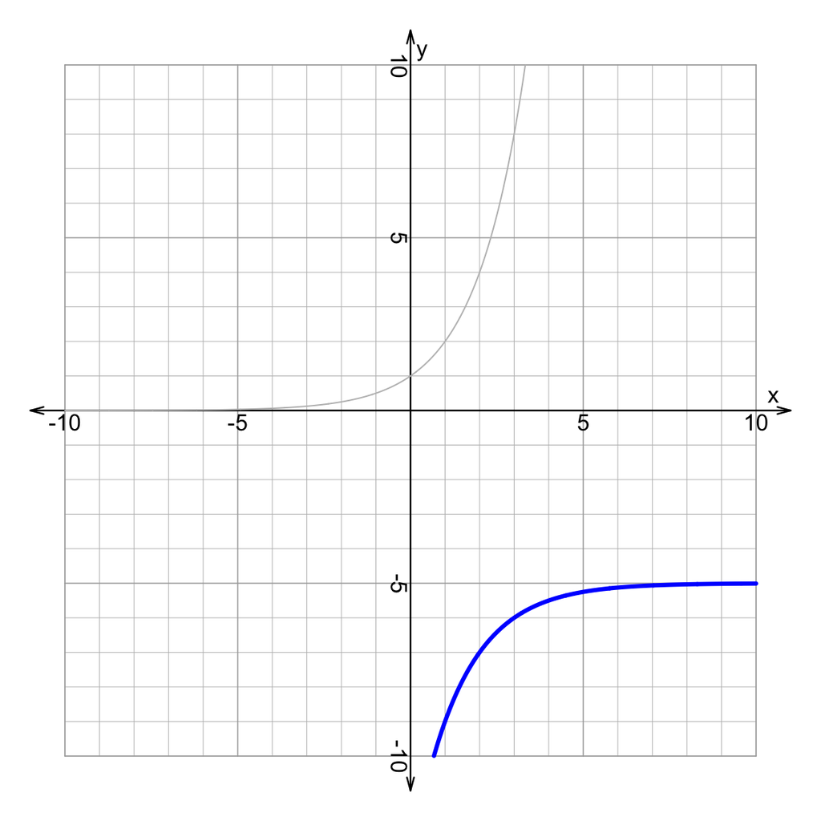

Find the parameters.

- $m=$ ##ANSWER1##
- $p=$ ##ANSWER2##
- $h=$ ##ANSWER3##
- $k=$ ##ANSWER4##

## Answerlist

- -1
- 1
- -1
- 1
- -5
- -4
- -3
- -2
- -1
- 0
- 1
- 2
- 3
- 4
- 5
- -5
- -4
- -3
- -2
- -1
- 0
- 1
- 2
- 3
- 4
- 5

# Solution

I’d recommend setting up the following equation in [Desmos](https://www.desmos.com/calculator). Let sliders represent the parameters, and see what each parameter does as you vary it.

$$y~=~ m \cdot
2^{\frac{1}{p}(x-h)}+k$$

It will help to first identify the reflections. There are both vertical and horizontal reflections, so $m=-1$ and $p=-1$. It is helpful to sketch the reflected parent function. In orange, I will sketch the reflected (but unshifted) transformation.

It also helps to sketch the horizontal asymptotes. Also, you’ll want to identify the point that is either 1 above or 1 below the asymptote. I’ve marked this point on both the orange and blue curves.

And finally, you’ll want to identify the displacements from the orange dot to the blue dot. These horizontal and vertical displacements show the values of $h$ and $k$.

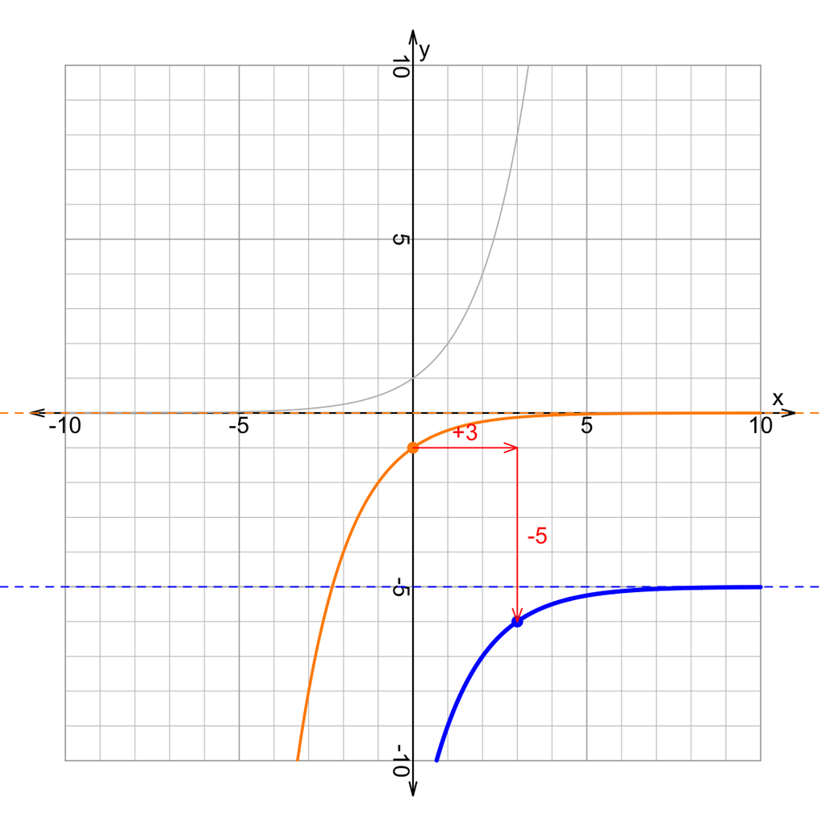

- $m=-1$
- $p=-1$
- $h=3$
- $k=-5$

And, thus, the equation of the blue curve is:

$$y=-2^{-(x-3)}-5$$

# Meta-information

extype: cloze exclozetype: schoice|schoice|schoice|schoice exsolution: 10|10|00000000100|10000000000 exname: exponential_params